# System Dynamics in health and care

fitting square data into round models

Sally Thompson

09 October 2023

## Health Data in the Headlines

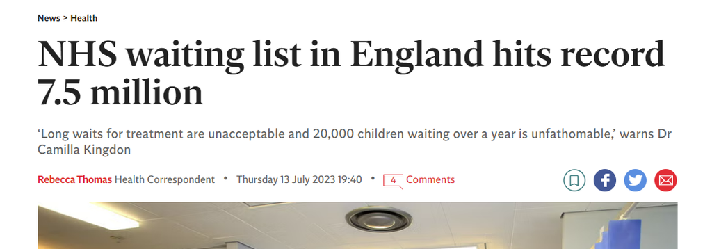

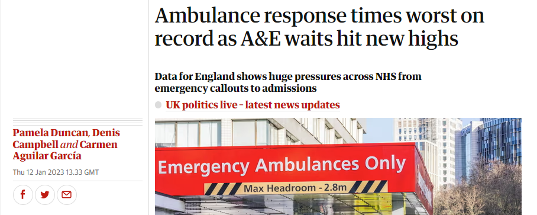

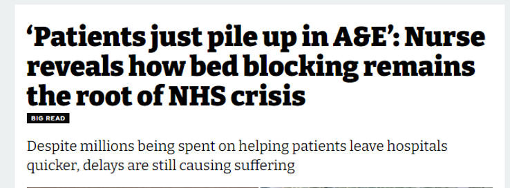

## Through the System Dynamics lens

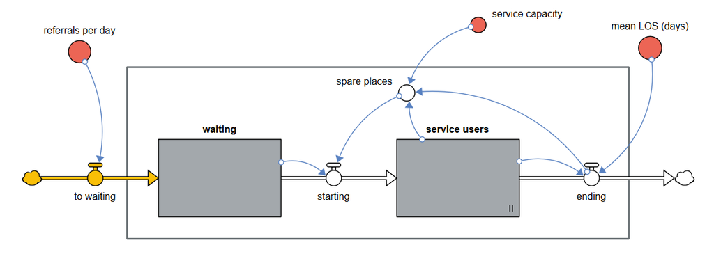

Stock-flow model

Dynamic behaviour, feedback loops

## Determining flows

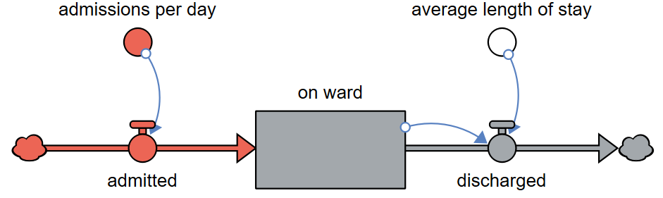

‘admissions per day’ is needed to populate the model.

‘discharged’ could be used to verify the model against known data

- How many admissions per day (or week, month…)

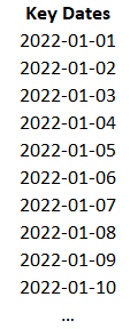

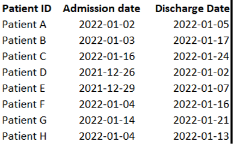

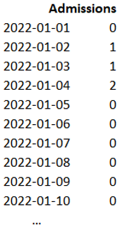

## Determining occupancy

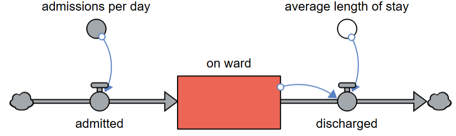

‘on ward’ is used to verify the model against known data

- Logic statement testing if the key date is wholly between admission and discharge dates
- flag for a match

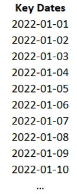

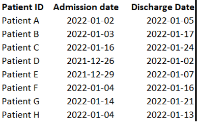

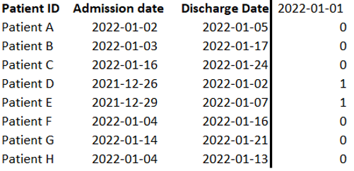

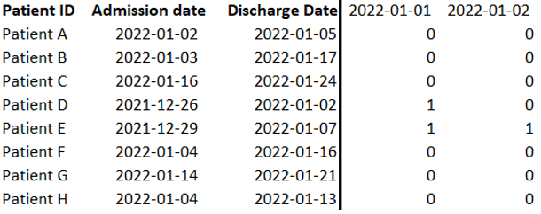

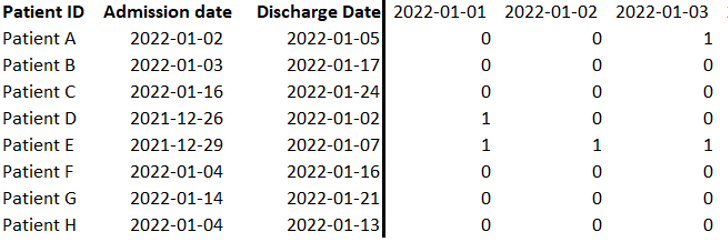

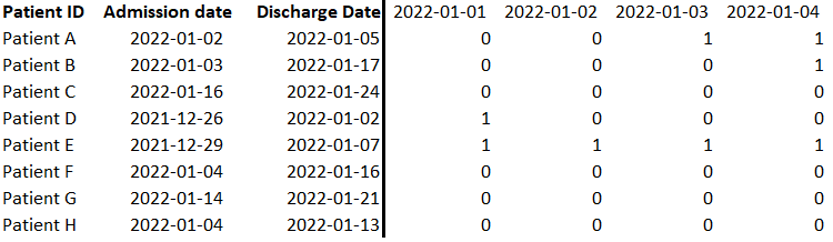

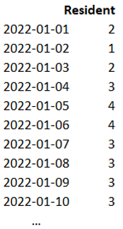

## in R - flows

Easy to do with `count`, or `group_by` and `summarise`

```r
admit_d <- spell_dates |>
  group_by(date_admit) |>
  count(date_admit)

head(admit_d)
```

```
# A tibble: 6 × 2
# Groups:   date_admit [6]
  date_admit     n
  <date>     <int>
1 2022-01-01    26
2 2022-01-02    25
3 2022-01-03    20
4 2022-01-04    22
5 2022-01-05    38
6 2022-01-06    27
```

## in R - occupancy

Generate list of key dates

```r
date_start <- dmy(01012022)
date_end <- dmy(31012022)
run_len <- length(seq(from = date_start, to = date_end, by = "day"))

keydates <- data.frame(
  date = c(seq(date_start, by = "day", length.out = run_len))
)
```

```
        date
1 2022-01-01
2 2022-01-02
3 2022-01-03
4 2022-01-04
5 2022-01-05
6 2022-01-06
```

## in R - occupancy

Iterate over each date - need to have been admitted before, and discharged after

```r
occupancy_flag <- function(df) {
  # pre-allocate tibble size to speed up iteration in loop
  activity_all <- tibble(nrow = nrow(df)) |>
    select()

  for (i in 1:run_len) {
    activity_period <- case_when(
      # creates 1 flag if resident for complete day
      df$date_admit < keydates$keydate[i] &
        df$date_discharge > keydates$keydate[i] ~
        1,
      TRUE ~ 0
    )

    # column bind this day's flags to previous
    activity_all <- bind_cols(activity_all, activity_period)
  }

  # rename column to match the day being counted
  activity_all <- activity_all |>
    setNames(paste0("d_", keydates$date))

  # bind flags columns to patient data
  daily_adm <- bind_cols(df, activity_all) |>
    pivot_longer(
      cols = starts_with("d_"),
      names_to = "date",
      values_to = "count"
    ) |>

    group_by(date) |>
    summarise(resident = sum(count)) |>
    ungroup() |>
    mutate(date = str_remove(date, "d_"))
}
```

Is there a better way than using a `for` loop?

## Longer Time Periods - flows

Use `lubridate::floor_date` to generate the date at start of week/month

```r
admit_wk <- spell_dates |>
  mutate(
    week_start = floor_date(
      date_admit,
      unit = "week",
      week_start = 1 # start week on Monday
    )
  ) |>
  count(week_start) # could add other parameters such as provider code, TFC etc

head(admit_wk)
```

```
# A tibble: 6 × 2
  week_start     n
  <date>     <int>
1 2021-12-27    51
2 2022-01-03   190
3 2022-01-10   183
4 2022-01-17   186
5 2022-01-24   203
6 2022-01-31   222
```

## Longer Time Periods - occupancy

Key dates to include the dates at the start and end of each time period

```r
date_start <- dmy(03012022) # first Monday of the year
date_end <- dmy(01012023)
run_len <- length(seq(from = date_start, to = date_end, by = "week"))

keydates <- data.frame(
  wk_start = c(seq(date_start, by = "week", length.out = run_len))
) |>
  mutate(
    wk_end = wk_start + 6
  ) # last date in time period
```

```
    wk_start     wk_end
1 2022-01-03 2022-01-09
2 2022-01-10 2022-01-16
3 2022-01-17 2022-01-23
4 2022-01-24 2022-01-30
5 2022-01-31 2022-02-06
6 2022-02-07 2022-02-13
```

## Longer Time Periods

More logic required if working in weeks or months - can only be in one place at any given time

```r
# flag for occupancy
activity_period <- case_when(
  # creates 1 flag if resident for complete week
  df$date_admit < keydates$wk_start[i] &
    df$date_discharge > keydates$wk_end[i] ~
    1,
  TRUE ~ 0
)
```

## Applying the data

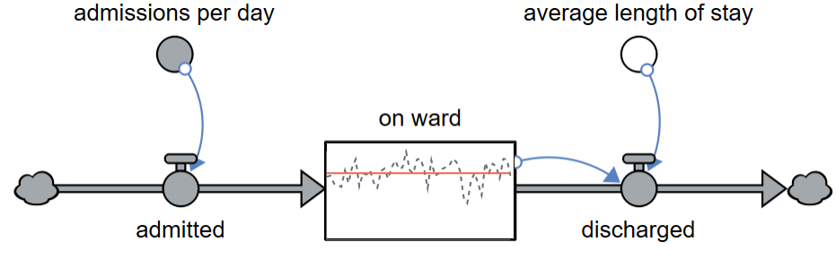

## Next Steps

- Generalise function to a state where it can be used by others - onto Github
- Turn this into a package
- Open-source SD models and interfaces - R Shiny or Python

## Questions, comments, suggestions?

Please get in touch!  
Sally.Thompson37@nhs.net